# Fujisaki

Set the right variables and load the package

The first step is to convert the PitchTiers into f0_ascii files.

Now convert the f0_ascii to the PAC files with `interpolate.exe` by Mixdorff. What I recommend to do is to use a Windows VM (I used Windows 10) and setup SSH.

You can run this by running the following command on Windows

```
@echo off & setlocal

cd Z:\01_Data\Preprocessed\Fujisaki\
for /r %%i in (*.f0_ascii) do (
    cd Z:\02_Scripts\Bash
    for /f "tokens=1 delims=." %%a in ("%%i") do (
      interpolation %%a%.f0_ascii 0 4 1e-006 auto 2
    )
)
```

In the next step, we’ll look at the optimal alpha and beta values. This is done with `explore_ft_space`.

## Phrase command

From these optimal hyper parameter combinations we can compute features on the phrase command

|  | name | num_phrases | Ap | T0 | reg_slope | reg_RMSE | naive_slope | naive_RMSE |
| --- | --- | --- | --- | --- | --- | --- | --- | --- |
| 1 | DF_ANG_VX1 | 1 | 0.73900 | -0.46 | -0.003836904 | 0.009014474 | -0.0034409529 | 0.022443360 |
| 2 | DF_ANG_VX10c | 2 | 0.07395 | NA | NA | NA | NA | NA |
| 3 | DF_ANG_VX11a | 1 | 0.25830 | -0.47 | -0.001377021 | 0.034902102 | -0.0015639914 | 0.079482718 |
| 4 | DF_ANG_VX12 | 1 | 0.28640 | -0.46 | -0.001097925 | 0.005779488 | -0.0009455769 | 0.009563485 |
| 5 | DF_ANG_VX13a | 1 | 1.18280 | -0.34 | -0.005092311 | 0.038778261 | -0.0040847909 | 0.067799577 |
| 6 | DF_ANG_VX14 | 1 | 0.65570 | -0.47 | -0.003469269 | 0.022504489 | -0.0031715768 | 0.038879622 |

We see that both slope computations (and also the RMSE) are highly correlated. Also we find a negative correlation between the amplitude and the slope

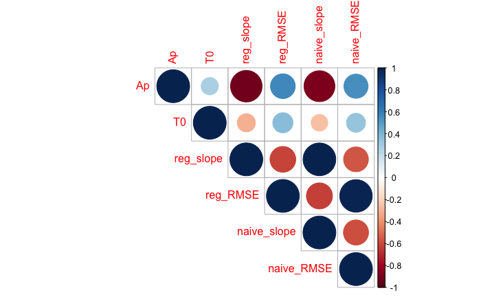

## Visualization

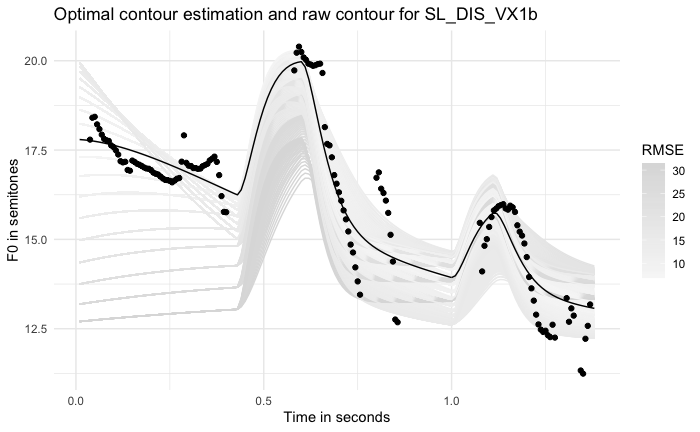